# Becerra-Gonzalez Wedding

COVID-19 Honor Code

Sunday, October 18, 2020

2020-10-04

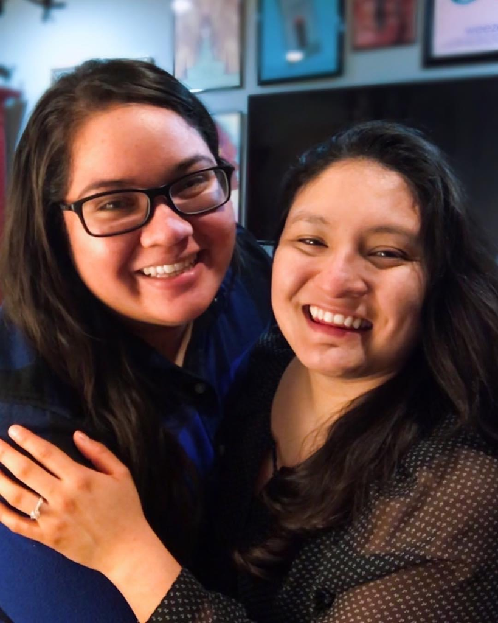

# Introduction

The Becerra-Gonzalez Wedding is in two weeks! We are now in the two-week period to take extra precautions not to get and spread COVID-19 for the wedding.

We have put together expectations for the Becerra-Gonzalez Wedding Honor Code. The purpose of the Honor Code is to outline behaviors we expect you to follow in the next two weeks to avoid spreading COVID-19 to the wedding party.

# Behavioral Expectations

Based on current recommendations from the [CDC](https://www.cdc.gov/coronavirus/2019-ncov/prevent-getting-sick/prevention.html), we expect you to adhere to the following behaviors before and during the wedding.

In the next two weeks I promise to:

1. Remain physically distanced from members outside of my household.
2. Wear my mask and wash my hands when out in public or when in contact with people outside my immediate household.
3. Monitor my health for symptoms of COVID-19 up to the wedding.
4. Take a COVID-19 test if I suspect to have been exposed to COVID-19 in the last two weeks of today’s date (October 4, 2020)

During the wedding, I promise to:

1. Wear my mask when indoors at all times, except when eating and drinking. I can take my mask off when outdoors.
2. Wash my hands often.
3. Keep physical distance as much as possible.

If everyone can adhere to these behaviors in these next two weeks, we may consider the event to be entirely maskless. However, if you cannot adhere to these behaviors, you will be required to wear a mask. Let us know if you cannot adhere to the behaviors set in this Honor Code.

Obviously, this is not a legal document. The point is to create shared expectations that we all follow to minimize the risk of getting each other sick. The only punishment that will come from this is the punishing guilt you will have knowing you potentially infected close friends and family.

Let’s all do our part to have a safe and fun wedding to celebrate our favorite ladies!

Sincerely,  
Becerra-Gonzalez Wedding Party

Please [see this link](https://www.health.harvard.edu/diseases-and-conditions/if-youve-been-exposed-to-the-coronavirus) if you think you have been exposed to the virus.